# Máster en Data Science para Finanzas

## Plantilla para proyectos de Machine Learning

Contacto: diego.bodas@cunef.edu

## Directrices antes de empezar (de cumplimiento obligatorio)

1. Esta plantilla es una guía, no una herramienta de copy/paste.
2. Es esencial entender el objetivo que persigues en cada proyecto desde el punto de vista de negocio. Una forma sencilla de documentar lo que estás haciendo es usar la plantilla de Machine Learning Canvas (https://www.ownml.co/machine-learning-canvas). Enlace a la versión word.docx), la puedes adaptar a tus necesidades.
3. Nuestro trabajo se expresa a través de un código informático que debe ser óptimo y usar correctamente organizado. Es preciso estandarizar organización de directorios, nombres de ficheros, etc. Uno de los estándares más conocidos se explica aquí: https://drivendata.github.io/cookiecutter-data-science/ Enlace a la plantilla base en formato zip Como trabajo autónomo queda pendiente aprender a trabajar con Github a nivel básico. Dos referencias útiles: https://lab.github.com/ y https://rogerdudler.github.io/git-guide/ Los notebooks los debes nombrar de forma que se sepa cual es el orden que hay que seguir, el nombre del notebook comenzará por un número de dos cifras (00, 01, 02...) y luego algo descriptivo en inglés. Por ejemplo: 00_LoadData_EDA
4. Es absolutamente **indispensable** comprender perfectamente los datos que manejas. *No se debe empezar ningún tipo de modelado sin entender perfectamente el significado, tipo de datos, descripción, interpretación de cada uno de los posibles valores, etc., de los datos que tenemos a nuestra disposición.* **El diccionario de datos es imprescindible**, y si no existe hay que crearlo. Debajo, un ejemplo de formato.
5. El proyecto no acaba cuando se entrega el modelo, hay que ponerlo en producción y monitorizar los resultados.
6. Es indispensable ser autónomo para generar código de calidad, lo que implica comentar correctamente el código, usar funciones, detectar y corregir errores... El soporte a la corrección de errores de código será mínimo. Solo se debe preguntar al profesor cuando se han ejecutado los pasos siguientes y aún así, y después de intentarlo varias veces, seguimos sin resolver el problema (el profesor se asegurará antes de analizar el error de que se han seguido todos estos pasos):
   - Hemos ejecutado línea a línea y sabemos en qué línea exacta ocurre el error (en fase de desarrollo, vamos ejecutando poco a poco para no encontrarnos con sorpresas inesperadas).
   - Hemos buscando el error en manuales, internet y, especialmente, https://stackoverflow.com/. Hacemos siempre las búsquedas **en inglés**.
   - Hemos probado diferentes alternativas para intentar analizar con qué tipo de entradas se produce el error y con cuáles no.
   - Hemos usado el foro de clase para preguntar sobre el error y compartir conocimiento con los compañeros.
7. Debes explicar todos los pasos que realizas, para eso usamos un notebook. Así mismo, toda gráfica debe tener su interpretación y conclusiones. Por ejemplo, si se dibujan los histogramas, ¿qué te dicen? ¿qué conclusiones puedes sacar?

### Ejemplo de diccinario de datos

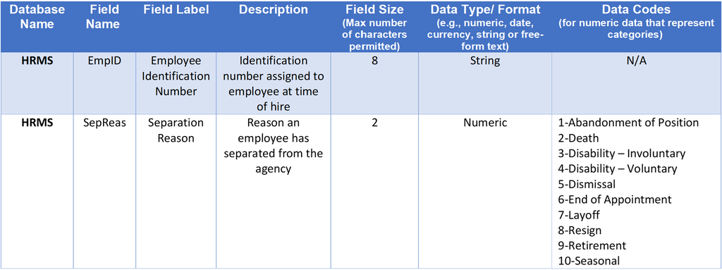

```python
# Check environment
import sys

print(sys.version)
print(sys.path)
print("---")
print(sys.executable)
```

```
3.8.11 (default, Aug  6 2021, 09:57:55) [MSC v.1916 64 bit (AMD64)]
['C:\\Users\\djbodas\\OneDrive - MAPFRE\\OneDrive\\2_MIS CLASES\\TrainingResources\\lending_club_A\\notebooks', 'C:\\Users\\djbodas\\Anaconda3\\envs\\main\\python38.zip', 'C:\\Users\\djbodas\\Anaconda3\\envs\\main\\DLLs', 'C:\\Users\\djbodas\\Anaconda3\\envs\\main\\lib', 'C:\\Users\\djbodas\\Anacond…
---
C:\Users\djbodas\Anaconda3\envs\main\python.exe
```

```python
# primero todas las librerías por bloques
import numpy as np
import pandas as pd
import matplotlib.pyplot as plt
import seaborn as sns
import warnings
warnings.filterwarnings("ignore")
```

```python
# opciones de visualización
pd.set_option('display.max_rows', 500)
pd.set_option('display.max_columns', 500)
```

# Bloque 1: cargar y entender los datos

Herramientas muy útiles en esta parte, recomendamos encarecidamente usar alguna (otra opción es tensorflow-data-validator, pero es algo más complicado de configurar y usar).

https://towardsdatascience.com/data-frame-eda-packages-comparison-pandas-profiling-sweetviz-and-pandasgui-bbab4841943b

### Read data

```python
df1 = pd.read_csv('../data/Loan_test_set.csv', skiprows=[0])
df2 = pd.read_csv('../data/Loan_training_set_1_4.csv', skiprows=[0])
df3 = pd.read_csv('../data/Loan_training_set_2_4.csv', skiprows=[0])
df4 = pd.read_csv('../data/Loan_training_set_3_4.csv', skiprows=[0])
df5 = pd.read_csv('../data/Loan_training_set_4_4.csv', skiprows=[0])
```

```python
# Tendré que juntarlo pero separando training y test
df1['test_set'] = 1
df2['test_set'] = 0
df3['test_set'] = 0
df4['test_set'] = 0
df5['test_set'] = 0
```